# 02CLUS_Fig2_H3k4me3_CORR_k6

Dr. Julio Domingo Cordero Henriquez

Department of Cardiovascular Genomics and Epigenomics, European Center for Angioscience (ECAS), Medical Faculty Mannheim, Heidelberg University, Mannheim, Germany

22 January 2024

# Contents

Mailto: julio.cordero@medma.uni-heidelberg.de

# 1 **Objective**

-To cluster the enrichment of H3K4me3 histone modification during the zebrafish heart regeneration.

# 2 General Comments on the Script

-This script shows how to obtain clusters from a **ChIP-seq** data used in different time points or conditions. The number of clusters is selected based on the **Elbow plot** and downstream analysis of the clusters with different barplots is also performed.

# 3 Summary of figures produced by this script.

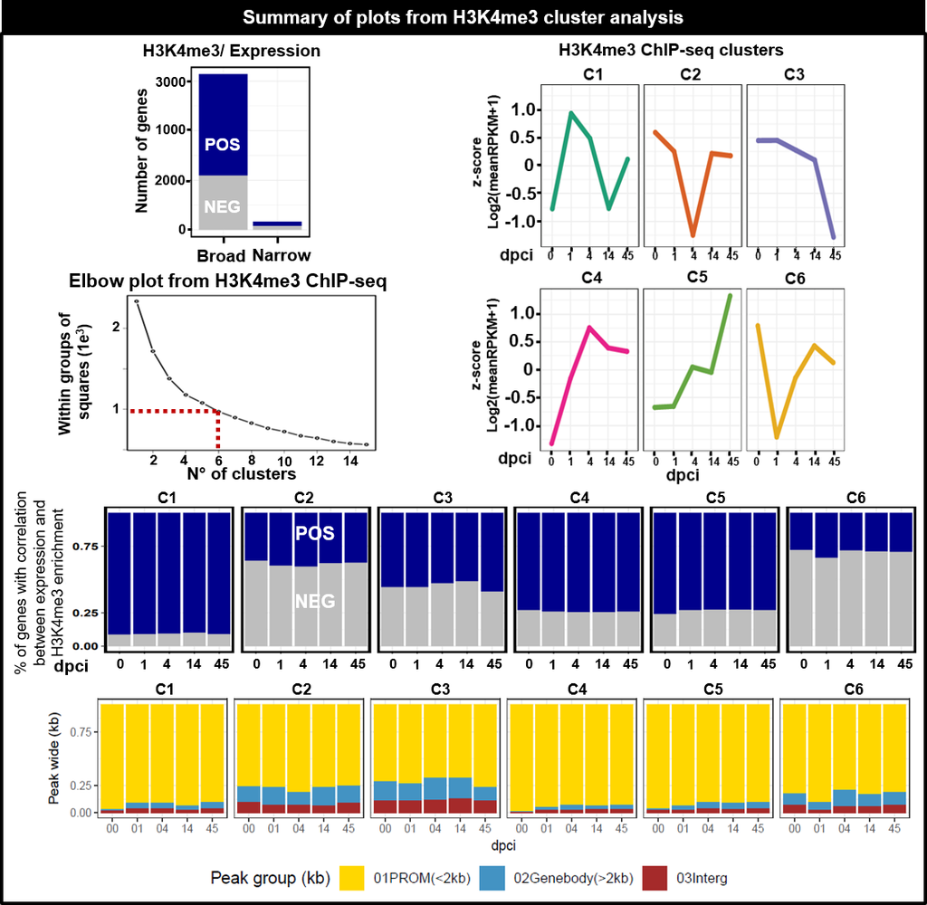

# 4 Set the working environment and Folder to output the results

- Important to keep the output files well organized follwoing the FAIR principles
- Findable, Accessible, Interoperable, and Reusable **(FAIR)**

```r
 workdir = "./"
setwd(workdir)
PTHA1="../03OUPUT/"
dir.create (PTHA1)
PROJECT="02CLUS_Fig2_H3k4me3_CORR_k6"
PROJECT2="02CLUS_Fig2_H3k4me3_CORR_k6"
PTHA=paste(PTHA1,PROJECT,"/",sep="")
PORT=paste(PTHA1,PROJECT,"/","00forNGS/",sep="")
PORT2=paste(PTHA1,PROJECT,"/","00forMOTIFs/",sep="")
PORT3=paste(PTHA1,PROJECT,"/","00GOs/",sep="")
dir.create (PTHA)
dir.create (PORT)
dir.create (PORT2)
dir.create (PORT3)


PEAK="Peak group"
NAME33b<-c("00", "01", "04", "14", "45")
```